# Mattia Piazzon - Esercizio 4

# 1 Punto 1

Leggiamo e visualizziamo i dati:

```r
setwd("~/MEGAsync/Universita/II Anno/Analisi dei Dati/Esami/SecondoAppello")
library(car)
cioccolato <- read.csv("cioccolato.csv")
head(cioccolato)
```

|  | X | calorie | grassi |
| --- | --- | --- | --- |
| 1 | 1 | 514.2857 | 31.42857 |
| 2 | 2 | 515.1515 | 30.30303 |
| 3 | 3 | 558.1395 | 39.53488 |
| 4 | 4 | 450.0000 | 37.50000 |
| 5 | 5 | 559.0000 | 50.10000 |
| 6 | 6 | 550.0000 | 37.50000 |

Visualizzo i dati tramite grafico:

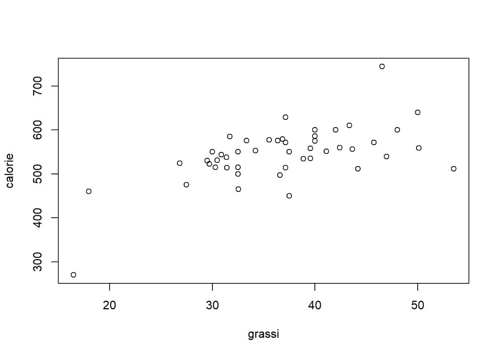

```r
plot(calorie ~ grassi, data = cioccolato)
```

Il grafico non è di facile interpretazione, sembrerebbe non essere lineare.

Creo comunque il modello di regressione:

```r
mod <- lm(calorie ~ grassi, data = cioccolato)
summary(mod)
```

```
##
## Call:
## lm(formula = calorie ~ grassi, data = cioccolato)
##
## Residuals:
##      Min       1Q   Median       3Q      Max
## -172.967  -21.854    6.862   31.043  153.164
##
## Coefficients:
##             Estimate Std. Error t value Pr(>|t|)
## (Intercept) 361.5677    37.7740   9.572 1.04e-12 ***
## grassi        4.9333     0.9999   4.934 1.01e-05 ***
## ---
## Signif. codes:  0 '***' 0.001 '**' 0.01 '*' 0.05 '.' 0.1 ' ' 1
##
## Residual standard error: 52.71 on 48 degrees of freedom
## Multiple R-squared:  0.3365, Adjusted R-squared:  0.3226
## F-statistic: 24.34 on 1 and 48 DF,  p-value: 1.01e-05
```

Analizzo i residui:

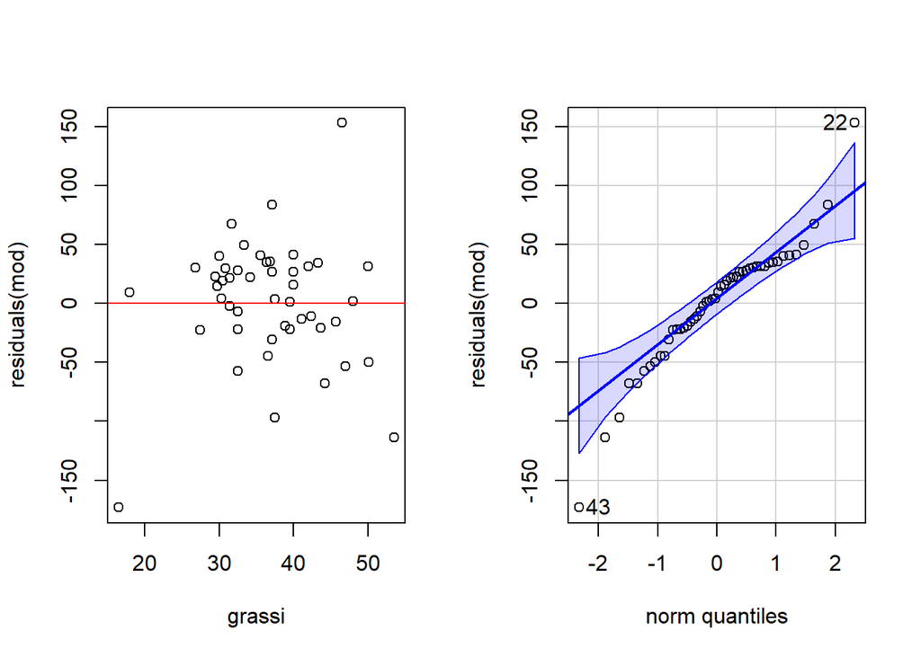

```
## [1] 43 22
```

```r
par(mfrow = c(1, 2))
plot(residuals(mod) ~ grassi, data = cioccolato)
abline(h = 0, col = "red")
qqPlot(residuals(mod))
```

L’analisi dei residui mostra che il modello di regressione non è appropriato, i residui non sono omoschedastici attorno ad h=0 e non senguono l’andamento normale nel qq-plot. Sembrebbe che ci sia un andamento non lineare.

Provo ad aggiungere un termine quadratico:

```r
mod_q <- lm(calorie ~ grassi + I(grassi^2), data = cioccolato)
summary(mod_q)
```

```
##
## Call:
## lm(formula = calorie ~ grassi + I(grassi^2), data = cioccolato)
##
## Residuals:
##     Min      1Q  Median      3Q     Max
## -110.34  -28.68    7.28   25.54  166.95
##
## Coefficients:
##              Estimate Std. Error t value Pr(>|t|)
## (Intercept)  48.11647  105.78809   0.455 0.651320
## grassi       23.16048    5.88318   3.937 0.000272 ***
## I(grassi^2)  -0.25336    0.08077  -3.137 0.002946 **
## ---
## Signif. codes:  0 '***' 0.001 '**' 0.01 '*' 0.05 '.' 0.1 ' ' 1
##
## Residual standard error: 48.44 on 47 degrees of freedom
## Multiple R-squared:  0.4513, Adjusted R-squared:  0.428
## F-statistic: 19.33 on 2 and 47 DF,  p-value: 7.479e-07
```

Analizzo i residui:

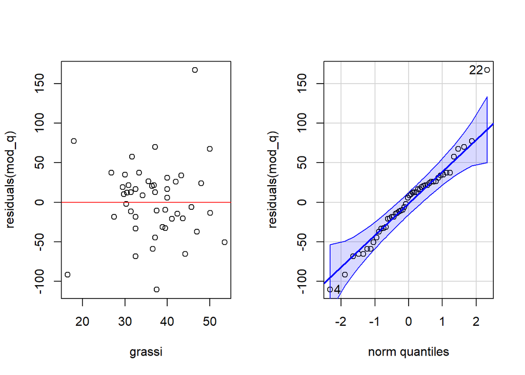

```
## [1] 22  4
```

```r
par(mfrow = c(1, 2))
plot(residuals(mod_q) ~ grassi, data = cioccolato)
abline(h = 0, col = "red")
qqPlot(residuals(mod_q))
```

L’analisi dei residui mostra che il modello è migliore, i residui sul grafico sono distribuiti in modo omogeneo attorno ad h=0 e il Q-Q plot mostra che i residui sono distribuiti in modo normale ad eccezione di un residuo nella coda destra. Inoltre noto che il coefficiente quadratico appena aggiunto è significativo.

Visualizzo il modello stimato:

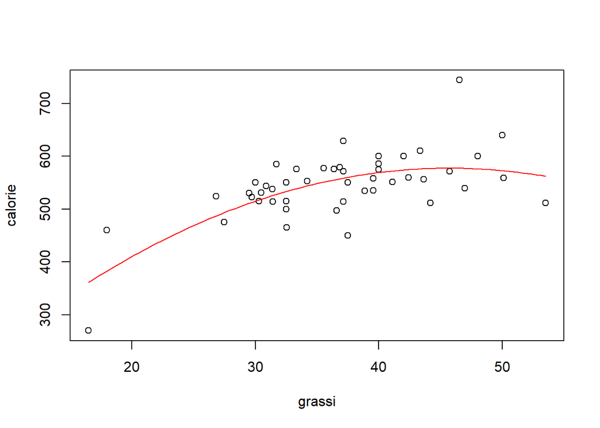

```r
plot(calorie ~ grassi, data = cioccolato)
curve(coef(mod_q)[1] + coef(mod_q)[2] * x + coef(mod_q)[3] * x ^ 2, add = TRUE, col = "red")
```

Il modello stimato spiega il 45.13% della variabilità dei dati e indica che la relazione fra calorie e percentuale di grassi è non lineare.

# 2 Punto 2

Calcoliamo l’intervallo di previsione al 93% per le calorie di una barretta di cioccolata di 50 grammi che contiene 15 grammi di grassi:

```r
pre <- predict(mod_q, newdata = data.frame(grassi = 15), interval = "prediction", level = 0.93)
pre
```

```
##        fit      lwr     upr
## 1 338.5166 224.8151 452.218
```

Se la barretta di cioccolata contenesse 20 grammi di grassi:

```r
pre <- predict(mod_q, newdata = data.frame(grassi = 20), interval = "prediction", level = 0.93)
pre
```

```
##        fit      lwr      upr
## 1 409.9801 310.2188 509.7415
```